# Comparative analysis of SVM core predictor genes against DEG & WGCNA

Emeline Favreau

2021/05/23

Copyright 2021 Emeline Favreau, University College London.

# Objective of analysis

## Analysis steps:

- Obtaining data
- Aim 1: Overlap of DEGs and SVM predictor genes
- Aim 2: Overlap of WGCNAs and SVM predictor genes

# Aim 1: Overlap of DEGs and SVM predictor genes

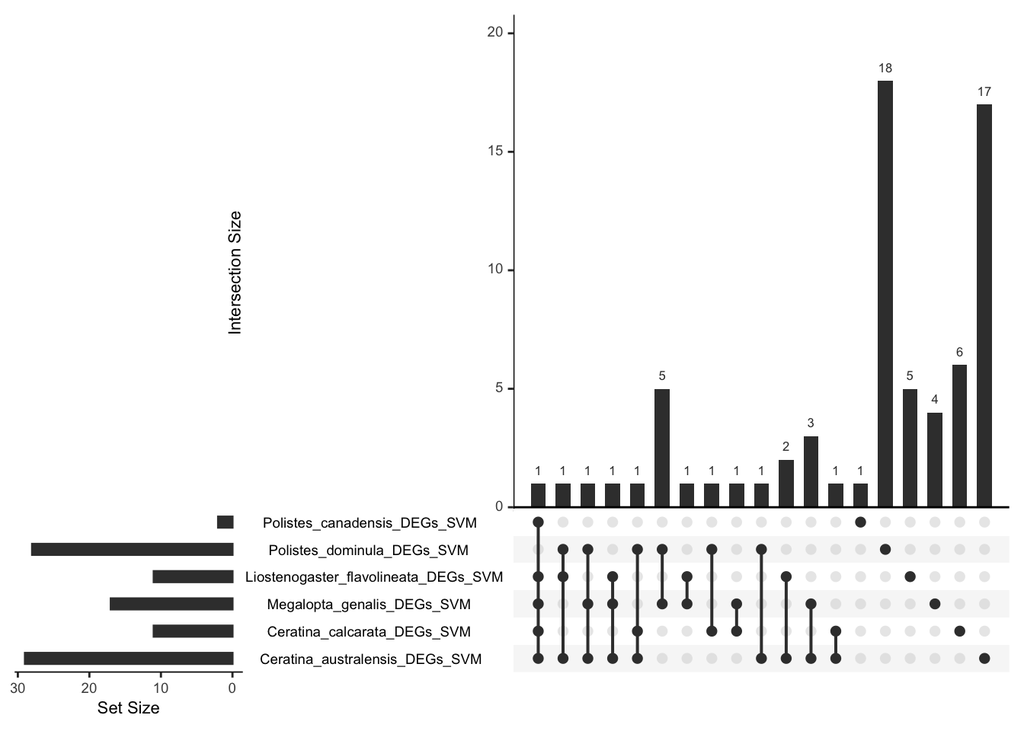

Most SVM common predictor genes are differentially expressed in one species only. See the last 5 vertical bars, for instance there are 18 SVM common predictor genes that are differentially expressed in *Polistes dominula* only.

Out of 132 SVM common predictor genes, there is not much overlap with DEGs. This is expected, because there is not many common DEGs across all species.

# Aim 2: Overlap of WGCNAs and SVM predictor genes

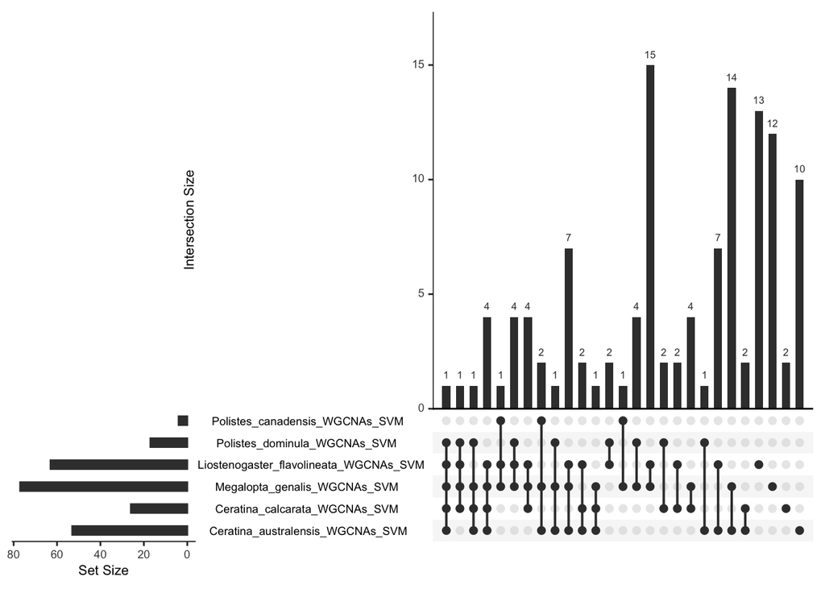

Out of 132 SVM common predictor genes, there is a bit of overlap with WGCNA genes. Maybe noteworthy: 15 genes between *L. flavolineata* and *M. genalis*; 1 gene between all but *P. canadensis*; 1 gene between the three bees.